# Hypothesis Testing in R

# Introduction to Hypothesis Testing

Hypothesis testing provides a framework for making statistical decisions using data. It’s a fundamental concept in inferential statistics that allows us to determine whether an observed effect or relationship in a sample can be generalized to the population.

## The Conceptual Framework

At its core, hypothesis testing involves:

1. Formulating a null hypothesis (H₀) and an alternative hypothesis (H₁)
2. Collecting data
3. Computing a test statistic
4. Determining the probability (p-value) of observing the test statistic if the null hypothesis is true
5. Making a decision based on the p-value and a pre-defined significance level (α)

From a mathematical perspective, we’re quantifying the evidence against H₀ and determining if this evidence is strong enough to reject H₀ in favor of H₁.

## Types of Hypothesis Tests

Different hypothesis tests are appropriate for different types of data and research questions. This notebook focuses on three common tests:

1. **Unpaired Two Sample t-test**: For comparing means between two independent groups
2. **Paired Two Sample t-test**: For comparing means between paired observations
3. **Analysis of Variance (ANOVA)**: For comparing means across three or more groups

Let’s explore each of these in detail.

# Unpaired Two Sample t-test

## Mathematical Foundation

The unpaired two-sample t-test (also called independent samples t-test) is used when:

- We have two independent samples from different populations
- The underlying data approximately follow a normal distribution
- We want to test if the population means are equal

The test statistic is calculated as:

$$t = \frac{\bar{X}_1 - \bar{X}_2}{s_p
\sqrt{\frac{1}{n_1} + \frac{1}{n_2}}}$$

Where: - $\bar{X}_1$ and $\bar{X}_2$ are the sample means - $s_p$ is the pooled standard deviation (when assuming equal variances) - $n_1$ and $n_2$ are the sample sizes

The pooled standard deviation is:

$$s_p = \sqrt{\frac{(n_1-1)s_1^2 +
(n_2-1)s_2^2}{n_1 + n_2 - 2}}$$

This follows a t-distribution with $n_1 + n_2 - 2$ degrees of freedom.

## Geometric Interpretation

Geometrically, the t-test can be visualized as measuring the overlap between two probability distributions. The greater the distance between the means (relative to the variability of the data), the less overlap there is, and the more likely we are to reject the null hypothesis.

[figure not shown]

## Example 1: Comparing Pulse Rates Between Genders

Let’s examine if there’s a difference in pulse rates between males and females.

### Data Preparation

```r
# Create the data frame
pulse <- data.frame(
  Males = c(65, 62, 63, 64, 64, 68, 66, 62, 62, 63),
  Females = c(64, 67, 66, 67, 66, 69, 63, 67, 62, 65)
)

# View the data
head(pulse)
```

|  | Males | Females |
| --- | --- | --- |
| 1 | 65 | 64 |
| 2 | 62 | 67 |
| 3 | 63 | 66 |
| 4 | 64 | 67 |
| 5 | 64 | 66 |
| 6 | 68 | 69 |

### Visual Exploration

Before conducting the test, let’s visualize the data:

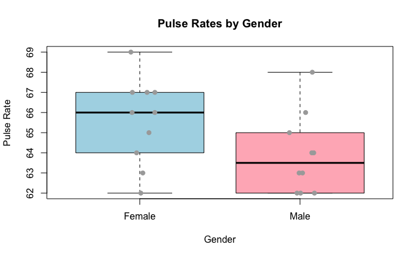

```r
# Reshape data for plotting
pulse_long <- data.frame(
  Pulse = c(pulse$Males, pulse$Females),
  Gender = factor(c(rep("Male", 10), rep("Female", 10)))
)

# Create boxplot
boxplot(Pulse ~ Gender, data = pulse_long,
        col = c("lightblue", "lightpink"),
        main = "Pulse Rates by Gender",
        ylab = "Pulse Rate")

# Add points to show the raw data
stripchart(Pulse ~ Gender, data = pulse_long,
           vertical = TRUE, method = "jitter",
           add = TRUE, pch = 19, col = "darkgray")
```

### Two-sided Test (Equal Variances)

We’ll test the null hypothesis that the means are equal against the alternative that they are different:

H₀: μₘ = μf  
H₁: μₘ ≠ μf

```r
# Conduct two-sided t-test with equal variances
t_test_result <- t.test(pulse$Males, pulse$Females,
                         alternative = "two.sided",
                         var.equal = TRUE)

# Display the result
t_test_result
```

```
    Two Sample t-test

data:  pulse$Males and pulse$Females
t = -1.8585, df = 18, p-value = 0.07952
alternative hypothesis: true difference in means is not equal to 0
95 percent confidence interval:
 -3.6217026  0.2217026
sample estimates:
mean of x mean of y
     63.9      65.6
```

### One-sided Test

Now, let’s test if the female pulse rate is higher than the male pulse rate:

H₀: μf = μm  
H₁: μf > μm

For this, we’ll reshape our data to use the formula interface in R:

```r
# Reshape data in a different format
pulse2 <- data.frame(
  Sex = factor(c(rep("Female", 10), rep("Male", 10))),
  Pulse = c(64, 67, 66, 67, 66, 69, 63, 67, 62, 65,
            65, 62, 63, 64, 64, 68, 66, 62, 62, 63)
)

# Conduct one-sided t-test
t_test_one_sided <- t.test(Pulse ~ Sex, data = pulse2,
                           alternative = "greater",
                           var.equal = TRUE)

# Display the result
t_test_one_sided
```

```
    Two Sample t-test

data:  Pulse by Sex
t = 1.8585, df = 18, p-value = 0.03976
alternative hypothesis: true difference in means between group Female and group Male is greater than 0
95 percent confidence interval:
 0.113861      Inf
sample estimates:
mean in group Female   mean in group Male
                65.6                 63.9
```

**Interpretation**: The p-value is 0.04, which is less than our significance level of 0.05. Therefore, we reject the null hypothesis and conclude that the female pulse rate is significantly higher than the male pulse rate.

### R Code Breakdown

In R, there are two ways to specify a t-test:

1. **Direct method**: `t.test(x, y, ...)` where x and y are vectors

   ```r
   t.test(pulse$Males, pulse$Females, alternative = "two.sided", var.equal = TRUE)
   ```

2. **Formula method**: `t.test(outcome ~ group, ...)`

   ```r
   t.test(Pulse ~ Sex, data = pulse2, alternative = "greater", var.equal = TRUE)
   ```

Key parameters: - `alternative`: Specifies the alternative hypothesis (“two.sided”, “less”, or “greater”) - `var.equal`: Whether to assume equal variances (TRUE) or not (FALSE) - `paired`: Whether the observations are paired (TRUE) or independent (FALSE)

## Statistical Considerations

1. **Equal vs. Unequal Variances**: The standard t-test assumes equal variances. If this assumption is violated, Welch’s t-test should be used (set `var.equal = FALSE` in R).
2. **Effect Size**: The t-test tells us if a difference is statistically significant, but not if it’s practically meaningful. For that, we can calculate Cohen’s d:

```r
# Calculate Cohen's d
cohens_d <- function(x1, x2) {
  m1 <- mean(x1)
  m2 <- mean(x2)
  s1 <- sd(x1)
  s2 <- sd(x2)
  n1 <- length(x1)
  n2 <- length(x2)

  # Pooled standard deviation
  s_pooled <- sqrt(((n1 - 1) * s1^2 + (n2 - 1) * s2^2) / (n1 + n2 - 2))

  # Cohen's d
  d <- (m1 - m2) / s_pooled
  return(d)
}

d <- cohens_d(pulse$Males, pulse$Females)
cat("Cohen's d:", round(d, 2), "\n")
```

```
Cohen's d: -0.83
```

# Paired Two Sample t-test

## Mathematical Foundation

The paired t-test is used when:

- We have pairs of observations
- Each pair is naturally related (e.g., before/after measurements on the same subject)
- We want to test if the mean difference is zero

The test statistic is calculated as:

$$t = \frac{\bar{d}}{s_d /
\sqrt{n}}$$

Where: - $\bar{d}$ is the mean of the differences - $s_d$ is the standard deviation of the differences - $n$ is the number of pairs

This follows a t-distribution with $n-1$ degrees of freedom.

## Geometric Interpretation

Geometrically, the paired t-test focuses on the distribution of differences between paired observations. If the null hypothesis is true (the mean difference is zero), the distribution of differences should be centered at zero.

## Example 2: Comparing Student Performance in Different Subjects

We’ll analyze if there’s a difference in student performance between Mathematics and Physics.

### Data Preparation

```r
# Create the data frame
grades <- data.frame(
  Student = 1:7,
  Maths = c(52, 48, 62, 70, 68, 42, 57),
  Physics = c(47, 63, 71, 75, 82, 45, 57)
)

# Calculate differences
grades$Diff <- grades$Physics - grades$Maths

# View the data
grades
```

| Student | Maths | Physics | Diff |
| --- | --- | --- | --- |
| 1 | 52 | 47 | -5 |
| 2 | 48 | 63 | 15 |
| 3 | 62 | 71 | 9 |
| 4 | 70 | 75 | 5 |
| 5 | 68 | 82 | 14 |
| 6 | 42 | 45 | 3 |
| 7 | 57 | 57 | 0 |

### Visual Exploration

Let’s visualize the paired data:

```r
# Plot the paired data
plot(grades$Maths, grades$Physics,
     xlab = "Mathematics Score", ylab = "Physics Score",
     main = "Math vs Physics Scores",
     pch = 19, col = "blue")

# Add diagonal line (x = y)
abline(0, 1, col = "red", lty = 2)
```

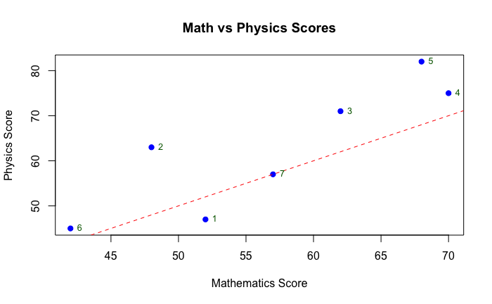

```r
# Add student IDs
text(grades$Maths, grades$Physics, labels = grades$Student,
     pos = 4, cex = 0.8, col = "darkgreen")
```

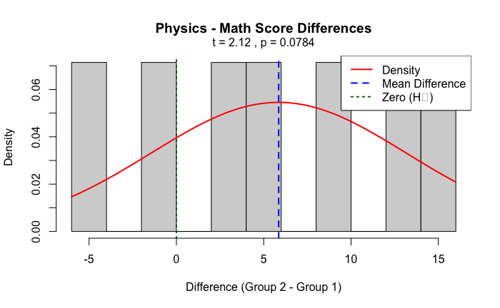

```r
# Visualize the differences
visualize_paired_test(grades$Diff, main = "Physics - Math Score Differences")
```

Points above the diagonal line represent students who performed better in Physics than in Mathematics.

### Conducting the Paired t-test

We’ll test the null hypothesis that there’s no difference in mean scores against the alternative that Physics scores are higher:

H₀: μₘ = μₚ (or μₚ - μₘ = 0)  
H₁: μₘ < μₚ (or μₚ - μₘ > 0)

```r
# Conduct the paired t-test (one-sided)
paired_test <- t.test(grades$Physics, grades$Maths,
                      paired = TRUE,
                      alternative = "greater")

# Display the result
paired_test
```

```
    Paired t-test

data:  grades$Physics and grades$Maths
t = 2.1191, df = 6, p-value = 0.03919
alternative hypothesis: true mean difference is greater than 0
95 percent confidence interval:
 0.486277      Inf
sample estimates:
mean difference
       5.857143
```

```r
# Calculate and summarize the differences
cat("Mean difference (Physics - Maths):", mean(grades$Diff), "\n")
```

```
Mean difference (Physics - Maths): 5.857143
```

### Alternative R Syntax

We can also use the formula syntax for paired tests:

```r
# Reshape data correctly for paired test with formula
grades_long <- data.frame(
  Subject = factor(rep(c("Maths", "Physics"), each = 7)),
  Score = c(grades$Maths, grades$Physics),
  Student = factor(rep(1:7, 2))
)

# Most straightforward approach - directly compare the vectors
t.test(grades$Physics, grades$Maths,
       paired = TRUE,
       alternative = "greater")  # Physics > Maths
```

```
    Paired t-test

data:  grades$Physics and grades$Maths
t = 2.1191, df = 6, p-value = 0.03919
alternative hypothesis: true mean difference is greater than 0
95 percent confidence interval:
 0.486277      Inf
sample estimates:
mean difference
       5.857143
```

## Statistical Considerations

1. **Correlation**: The paired t-test is more powerful than an independent t-test when the pairs are positively correlated:

```r
# Calculate correlation between Maths and Physics scores
cor_val <- cor(grades$Maths, grades$Physics)
cat("Correlation between Maths and Physics scores:", round(cor_val, 2), "\n")
```

```
Correlation between Maths and Physics scores: 0.86
```

2. **Effect Size**: For paired tests, we can calculate Cohen’s d for repeated measures:

```r
# Cohen's d for paired data
cohens_d_paired <- mean(grades$Diff) / sd(grades$Diff)
cat("Cohen's d (paired):", round(cohens_d_paired, 2), "\n")
```

```
Cohen's d (paired): 0.8
```

This is a large effect size, consistent with our statistically significant result.

# Analysis of Variance (ANOVA)

## Mathematical Foundation

ANOVA is used when:

- We have three or more groups
- We want to test if at least one group mean differs from the others

The test statistic is the F-ratio:

$$F = \frac{\text{Between-group
variability}}{\text{Within-group variability}}$$

Specifically:

$$F = \frac{MSB}{MSW}$$

Where: - MSB is the Mean Square Between groups - MSW is the Mean Square Within groups

This follows an F-distribution with $(k-1, N-k)$ degrees of freedom, where $k$ is the number of groups and $N$ is the total sample size.

## Geometric Interpretation

Geometrically, ANOVA can be visualized as comparing the variability between group means to the variability within groups. When between-group variability is large relative to within-group variability, we have evidence that at least one group differs from others.

## Example 3: Comparing the Effects of Different Grip Types

We’ll analyze if there’s a difference in upper body power (UBP) among three types of ski pole grips.

### Data Preparation

```r
# Create the data frame
grip_data <- data.frame(
  ubp = c(168.2, 161.4, 163.2, 166.7, 173.0, 173.3, 160.1, 161.2, 166.8),
  grip = factor(c(rep("classic", 3), rep("integrated", 3), rep("modern", 3)))
)

# View the data
grip_data
```

| ubp | grip |
| --- | --- |
| 168.2 | classic |
| 161.4 | classic |
| 163.2 | classic |
| 166.7 | integrated |
| 173.0 | integrated |
| 173.3 | integrated |
| 160.1 | modern |
| 161.2 | modern |
| 166.8 | modern |

### Visual Exploration

Let’s visualize the data:

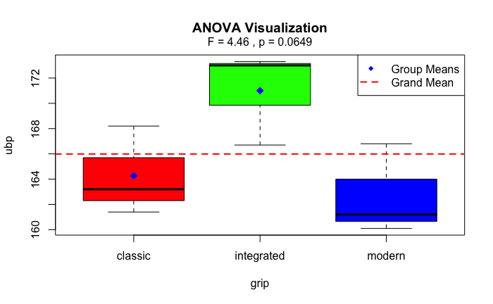

```r
# Visualize ANOVA
visualize_anova(grip_data, "grip", "ubp")
```

The visualization shows the distribution of UBP values for each grip type, with the group means (blue diamonds) and the grand mean (red dashed line).

### Conducting ANOVA

We’ll test the null hypothesis that all group means are equal:

H₀: μ₁ = μ₂ = μ₃  
H₁: At least one mean differs

```r
# Fit the ANOVA model
anova_model <- aov(ubp ~ grip, data = grip_data)

# Display the ANOVA table
summary(anova_model)
```

```
            Df Sum Sq Mean Sq F value Pr(>F)
grip         2 116.68   58.34   4.463 0.0649 .
Residuals    6  78.43   13.07
---
Signif. codes:  0 ‘***’ 0.001 ‘**’ 0.01 ‘*’ 0.05 ‘.’ 0.1 ‘ ’ 1
```

**Interpretation**: The p-value is 0.0649, which is slightly above our significance level of 0.05. Therefore, we fail to reject the null hypothesis and conclude that there is insufficient evidence to suggest a difference in mean UBP among the three grip types.

### Understanding the ANOVA Table

The ANOVA table provides:

1. **Source of Variation**: Between groups (grip) and within groups (Residuals)
2. **Degrees of Freedom (Df)**: k-1 for between groups and N-k for within groups
3. **Sum of Squares (Sum Sq)**: Total variability
4. **Mean Squares (Mean Sq)**: Sum of squares divided by degrees of freedom
5. **F value**: Ratio of between-group variability to within-group variability
6. **Pr(>F)**: P-value for the F statistic

## Post-hoc Tests

If the ANOVA is significant, we typically conduct post-hoc tests to determine which specific groups differ. Even though our ANOVA wasn’t significant, let’s demonstrate how to perform these tests:

```r
# Tukey's Honest Significant Difference test
TukeyHSD(anova_model)
```

```
  Tukey multiple comparisons of means
    95% family-wise confidence level

Fit: aov(formula = ubp ~ grip, data = grip_data)

$grip
                        diff        lwr        upr     p adj
integrated-classic  6.733333  -2.324093 15.7907600 0.1349973
modern-classic     -1.566667 -10.624093  7.4907600 0.8595955
modern-integrated  -8.300000 -17.357427  0.7574266 0.0687977
```

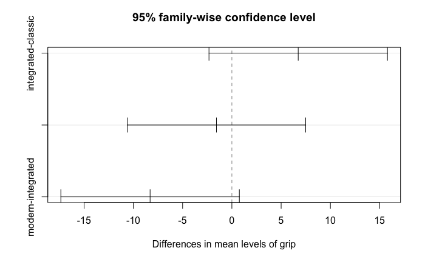

```r
# Visualize the Tukey's test results
plot(TukeyHSD(anova_model))
```

Tukey’s HSD test compares all pairs of groups and adjusts p-values for multiple comparisons.

## Statistical Considerations

1. **Assumptions**: ANOVA assumes normality, homogeneity of variances, and independence of observations.
2. **Effect Size**: We can calculate eta-squared (η²) to measure the proportion of variance explained:

```r
# Calculate eta-squared
anova_table <- summary(anova_model)[[1]]
eta_squared <- anova_table[1, "Sum Sq"] / sum(anova_table[, "Sum Sq"])
cat("Eta-squared:", round(eta_squared, 3), "\n")
```

```
Eta-squared: 0.598
```

# Connecting the Tests: A Unified Framework

## Linear Models Perspective

All the tests we’ve explored can be formulated as linear models:

```r
# T-test as a linear model
lm_ttest <- lm(Pulse ~ Sex, data = pulse2)
summary(lm_ttest)
```

```
Call:
lm(formula = Pulse ~ Sex, data = pulse2)

Residuals:
   Min     1Q Median     3Q    Max
-3.600 -1.675  0.100  1.400  4.100

Coefficients:
            Estimate Std. Error t value Pr(>|t|)
(Intercept)  65.6000     0.6468 101.424   <2e-16 ***
SexMale      -1.7000     0.9147  -1.859   0.0795 .
---
Signif. codes:  0 ‘***’ 0.001 ‘**’ 0.01 ‘*’ 0.05 ‘.’ 0.1 ‘ ’ 1

Residual standard error: 2.045 on 18 degrees of freedom
Multiple R-squared:  0.161, Adjusted R-squared:  0.1144
F-statistic: 3.454 on 1 and 18 DF,  p-value: 0.07952
```

```r
# ANOVA as a linear model
lm_anova <- lm(ubp ~ grip, data = grip_data)
summary(lm_anova)
```

```
Call:
lm(formula = ubp ~ grip, data = grip_data)

Residuals:
   Min     1Q Median     3Q    Max
-4.300 -2.600 -1.067  2.300  4.100

Coefficients:
               Estimate Std. Error t value Pr(>|t|)
(Intercept)     164.267      2.087  78.696 2.83e-10 ***
gripintegrated    6.733      2.952   2.281   0.0627 .
gripmodern       -1.567      2.952  -0.531   0.6147
---
Signif. codes:  0 ‘***’ 0.001 ‘**’ 0.01 ‘*’ 0.05 ‘.’ 0.1 ‘ ’ 1

Residual standard error: 3.615 on 6 degrees of freedom
Multiple R-squared:  0.598, Adjusted R-squared:  0.464
F-statistic: 4.463 on 2 and 6 DF,  p-value: 0.06495
```

This connection reveals that: - A t-test is a special case of ANOVA with two groups - The t-statistic squared equals the F-statistic when comparing two groups - All these tests are part of the general linear model framework

## Choosing the Right Test

Here’s a decision tree for selecting the appropriate test:

1. **One sample?** → One-sample t-test
2. **Two samples?**
   - **Paired observations?** → Paired t-test
   - **Independent observations?** → Independent t-test
3. **Three or more samples?**
   - **One factor?** → One-way ANOVA
   - **Two or more factors?** → Factorial ANOVA

# Practical Tips for Effective Hypothesis Testing in R

1. **Always visualize your data first**

   ```r
   boxplot(y ~ group)  # For categorical predictors
   plot(y ~ x)         # For continuous predictors
   ```

2. **Check assumptions**

   ```r
   # Normality check
   shapiro.test(residuals(model))

   # Equal variance check
   bartlett.test(y ~ group)
   ```

3. **Use appropriate syntax for your data structure**

   ```r
   # For wide format data
   t.test(group1, group2, paired = TRUE)

   # For long format data
   t.test(outcome ~ group, data = df, paired = FALSE)
   ```

4. **Report effect sizes along with p-values**

   ```r
   # Cohen's d for t-tests
   d <- mean_diff / pooled_sd

   # Eta-squared for ANOVA
   eta_sq <- sum_sq_between / sum_sq_total
   ```

5. **Use diagnostic plots for ANOVA**

   ```r
   model <- aov(y ~ group)
   plot(model)  # Show diagnostic plots
   ```

# Conclusion

Hypothesis testing provides a framework for making statistical inferences from data. By understanding both the mathematical foundations and the practical implementation in R, you can effectively analyze your data and draw meaningful conclusions.

Remember that hypothesis testing is just one tool in the statistical toolkit. It’s important to combine it with effect size measures, confidence intervals, and thoughtful interpretation to develop a comprehensive understanding of your data.

# R Code Reference Sheet

```r
# Creating example data to use in the examples
# Example data for independent t-test
x <- c(4, 5, 6, 5, 4)
y <- c(2, 3, 1, 2, 2)

# Example data for formula-based t-test
df_ttest <- data.frame(
  outcome = c(x, y),
  group = factor(c(rep("A", length(x)), rep("B", length(y))))
)

# Example data for paired t-test
before <- c(5, 6, 4, 7, 5)
after <- c(7, 8, 6, 8, 9)

# Example data for formula-based paired t-test
df_paired <- data.frame(
  score = c(before, after),
  time = factor(c(rep("Before", length(before)), rep("After", length(after)))),
  subject = factor(rep(1:length(before), 2))
)

# Example data for ANOVA
group1 <- c(18, 21, 16, 22, 19)
group2 <- c(22, 25, 17, 24, 16)
group3 <- c(15, 12, 16, 11, 14)

df_anova <- data.frame(
  outcome = c(group1, group2, group3),
  group = factor(c(rep("A", length(group1)),
                   rep("B", length(group2)),
                   rep("C", length(group3))))
)

# Now we can run our examples with actual data
```

After getting data

```r
# Independent t-test - direct method
t_test_result <- t.test(x, y, alternative = "two.sided", var.equal = TRUE)
t_test_result

# Independent t-test - formula method
t_test_formula <- t.test(outcome ~ group, data = df_ttest,
                         alternative = "two.sided", var.equal = TRUE)
t_test_formula

# Paired t-test - direct method
paired_test <- t.test(after, before, paired = TRUE)
paired_test

# One-way ANOVA
anova_model <- aov(outcome ~ group, data = df_anova)
summary(anova_model)

# Post-hoc tests (only if ANOVA is significant)
TukeyHSD(anova_model)

# Effect sizes
# Cohen's d for t-test
cohens_d <- function(x1, x2) {
  m1 <- mean(x1)
  m2 <- mean(x2)
  s1 <- sd(x1)
  s2 <- sd(x2)
  n1 <- length(x1)
  n2 <- length(x2)
  s_pooled <- sqrt(((n1-1)*s1^2 + (n2-1)*s2^2) / (n1+n2-2))
  d <- (m1 - m2) / s_pooled
  return(d)
}

# Calculate Cohen's d for our t-test example
d_value <- cohens_d(x, y)
cat("Cohen's d:", round(d_value, 2), "\n")

# Eta-squared for ANOVA
eta_squared <- function(model) {
  anova_table <- summary(model)[[1]]
  ss_effect <- anova_table[1, "Sum Sq"]
  ss_total <- sum(anova_table[, "Sum Sq"])
  return(ss_effect / ss_total)
}

# Calculate eta-squared for our ANOVA example
eta_sq <- eta_squared(anova_model)
cat("Eta-squared:", round(eta_sq, 3), "\n")
```